| title: “airfare_exercise” |
| --- |
| author: “Walter J.T.V” |
| date: “2024-10-21” |
| output: html_document |

# Introduction

```r
library(moments)
library(corrplot)
load("01- Airfare-raw.RData")
summary(air)
```

```
##       year         origin             destin                id
##  Min.   :1997   Length:4596        Length:4596        Min.   :   1
##  1st Qu.:1998   Class :character   Class :character   1st Qu.: 288
##  Median :1998   Mode  :character   Mode  :character   Median : 575
##  Mean   :1998                                         Mean   : 575
##  3rd Qu.:1999                                         3rd Qu.: 862
##  Max.   :2000                                         Max.   :1149
##       dist            passen            fare          bmktshr
##  Min.   :  95.0   Min.   :   2.0   Min.   : 37.0   Min.   :0.1605
##  1st Qu.: 505.0   1st Qu.: 215.0   1st Qu.:123.0   1st Qu.:0.4650
##  Median : 861.0   Median : 357.0   Median :168.0   Median :0.6039
##  Mean   : 989.7   Mean   : 636.8   Mean   :178.8   Mean   :0.6101
##  3rd Qu.:1304.0   3rd Qu.: 717.0   3rd Qu.:225.0   3rd Qu.:0.7531
##  Max.   :2724.0   Max.   :8497.0   Max.   :522.0   Max.   :1.0000
##      ldist            y98            y99            y00           lfare
##  Min.   :4.554   Min.   :0.00   Min.   :0.00   Min.   :0.00   Min.   :3.611
##  1st Qu.:6.225   1st Qu.:0.00   1st Qu.:0.00   1st Qu.:0.00   1st Qu.:4.812
##  Median :6.758   Median :0.00   Median :0.00   Median :0.00   Median :5.124
##  Mean   :6.696   Mean   :0.25   Mean   :0.25   Mean   :0.25   Mean   :5.096
##  3rd Qu.:7.173   3rd Qu.:0.25   3rd Qu.:0.25   3rd Qu.:0.25   3rd Qu.:5.416
##  Max.   :7.910   Max.   :1.00   Max.   :1.00   Max.   :1.00   Max.   :6.258
##     ldistsq          concen          lpassen
##  Min.   :20.74   Min.   :0.1605   Min.   :0.6931
##  1st Qu.:38.75   1st Qu.:0.4650   1st Qu.:5.3706
##  Median :45.67   Median :0.6039   Median :5.8777
##  Mean   :45.28   Mean   :0.6101   Mean   :6.0170
##  3rd Qu.:51.45   3rd Qu.:0.7531   3rd Qu.:6.5751
##  Max.   :62.57   Max.   :1.0000   Max.   :9.0475
```

```r
#Take the subset of data of year 2020
df <- air[air$year == 2000, ]

names(df)
```

```
##  [1] "year"    "origin"  "destin"  "id"      "dist"    "passen"  "fare"
##  [8] "bmktshr" "ldist"   "y98"     "y99"     "y00"     "lfare"   "ldistsq"
## [15] "concen"  "lpassen"
```

# Solution

## 1. Determine if the response variable (fare) has an acceptably normal distribution.

```r
mm <- mean(df$fare)
ss <- sd(df$fare)

mm;ss
```

```
## [1] 188.0235
```

```
## [1] 76.84232
```

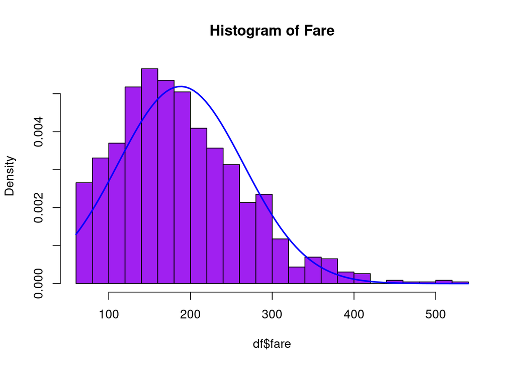

```r
?hist
hist(df$fare, col="purple",freq=F,30, main="Histogram of Fare")
curve(dnorm(x, mean=mm, sd=ss), add=T, lwd=2, col="blue")
```

```r
#Using a shapiro test to assess if the distribution is Normal
# Conclusion: we reject that is normal
shapiro.test(df$fare)
```

```
##
##  Shapiro-Wilk normality test
##
## data:  df$fare
## W = 0.95733, p-value < 2.2e-16
```

```r
#using a kolmogorov test
#ks.test(df$fare, pnorm())

# Looking at the skewness of the data we can asses if its not normal
?skewness
skewness(df$fare)
```

```
## [1] 0.8323212
```

## 2. Value the descriptive statistics of the variables fare (fare), market share of the largest operator (bmktshr), distance (dist) and number of daily passengers (passen).

```r
df1 <- df[, c("fare", "dist", "passen", "concen")]
summary(df1)
```

```
##       fare          dist            passen           concen
##  Min.   : 62   Min.   :  95.0   Min.   :   2.0   Min.   :0.1797
##  1st Qu.:132   1st Qu.: 505.0   1st Qu.: 228.0   1st Qu.:0.4562
##  Median :178   Median : 861.0   Median : 378.0   Median :0.5872
##  Mean   :188   Mean   : 989.7   Mean   : 670.9   Mean   :0.6016
##  3rd Qu.:233   3rd Qu.:1304.0   3rd Qu.: 759.0   3rd Qu.:0.7381
##  Max.   :522   Max.   :2724.0   Max.   :8497.0   Max.   :1.0000
```

## 3. Indicate by exploration of the data which are apparently the variables most associated with the response variable (use only the indicated variables).

Looking at correlation matrices we see that Fare ~ Dist are related and also Dist ~ Concen a bit.

```r
#Lets use spearman correlation given that Pearson one is not suitable for NON-NORMAL distributions (Any kind)
corr_matrix <- cor(df1, method="spearman")
corr_matrix
```

```
##              fare        dist      passen      concen
## fare    1.0000000  0.54240632 -0.21296647 -0.18752534
## dist    0.5424063  1.00000000 -0.05980684 -0.51354821
## passen -0.2129665 -0.05980684  1.00000000 -0.06072318
## concen -0.1875253 -0.51354821 -0.06072318  1.00000000
```

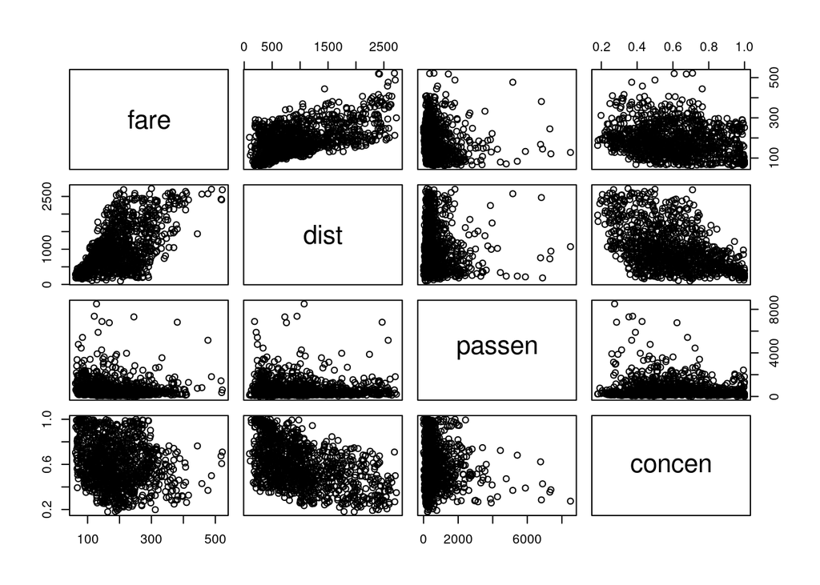

```r
plot(df1)
```

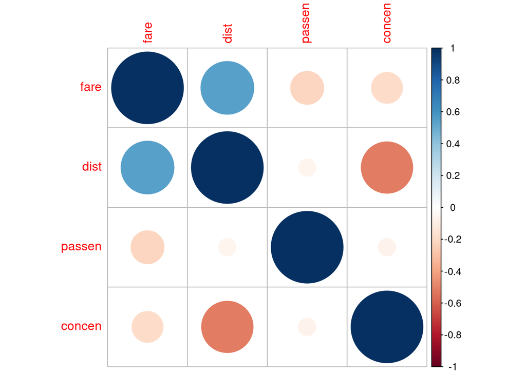

```r
corrplot(corr_matrix)
```

```r
#If we maunally to test if R = 0
cor.test(df$fare, df$passen, method="spearman")
```

```
##
##  Spearman's rank correlation rho
##
## data:  df$fare and df$passen
## S = 306660121, p-value = 2.989e-13
## alternative hypothesis: true rho is not equal to 0
## sample estimates:
##        rho
## -0.2129665
```

## 4. Define a polyeconomic factor f.concen for the covariate of the market share of the main operator (concen) according to its quartiles and argue if the average rate depends on the level of concentration of the path. Statistically justify the answer.

```r
#Convert numeric to factors
?cut
#This is not correct because it doesnt follow quantiles
#df$f.concen <- cut(df$concen, breaks=c(0, 0.2, 0.4, 0.6, 0.8, 1), include.lowest=T)
df$f.concen <- cut(df$concen, breaks=quantile(df$concen), include.lowest=T)
summary(df$f.concen)
```

```
##  [0.18,0.456] (0.456,0.587] (0.587,0.738]     (0.738,1]
##           288           287           287           287
```

## 5. Calculate and interpret the anova model of a route that explains the rate according to the concentration factor of the main operator (concentration factor created in point 4).

Not all means are the same as seen in the oneway ANOVA test. Given that it feels we dig deeper doing pairwise tests with WILCOX (non-parametric given that FARE is not normally distributed). We clearly see that all of them are different (We reject the equality H0 that both means are equal) except for the 2nd bin and the 3rd bin of the categorical variable f.concen.

```r
tapply(df$fare, df$f.concen, summary)
```

```
## $`[0.18,0.456]`
##    Min. 1st Qu.  Median    Mean 3rd Qu.    Max.
##    68.0   158.5   193.0   207.7   239.0   477.0
##
## $`(0.456,0.587]`
##    Min. 1st Qu.  Median    Mean 3rd Qu.    Max.
##    67.0   132.0   173.0   187.5   231.5   488.0
##
## $`(0.587,0.738]`
##    Min. 1st Qu.  Median    Mean 3rd Qu.    Max.
##    62.0   124.5   173.0   187.8   235.0   522.0
##
## $`(0.738,1]`
##    Min. 1st Qu.  Median    Mean 3rd Qu.    Max.
##    63.0   111.5   159.0   169.0   225.5   444.0
```

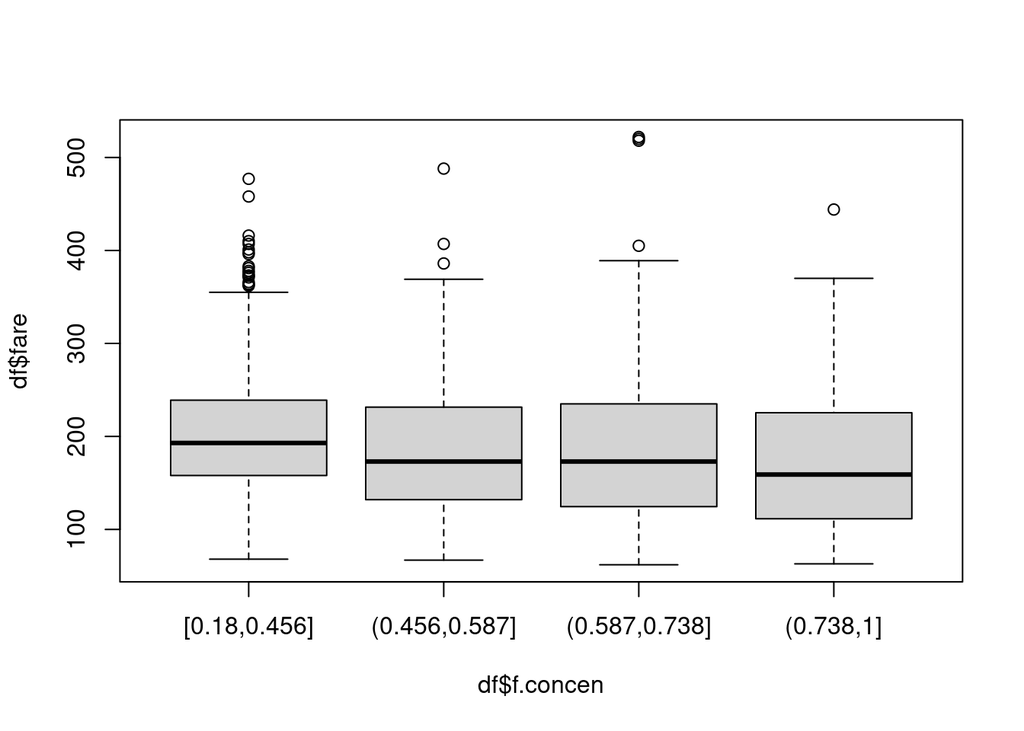

```r
boxplot(df$fare ~ df$f.concen)
```

```r
# If Y normally distributed then :
# HO: all means in the group are the same
oneway.test(df$fare ~ df$f.concen)
```

```
##
##  One-way analysis of means (not assuming equal variances)
##
## data:  df$fare and df$f.concen
## F = 13.755, num df = 3.00, denom df = 635.12, p-value = 1.06e-08
```

```r
# Given that Y is not normally distributed this test will perform better
# H0: all means in the group are the same
kruskal.test(df$fare ~ df$f.concen)
```

```
##
##  Kruskal-Wallis rank sum test
##
## data:  df$fare by df$f.concen
## Kruskal-Wallis chi-squared = 37.599, df = 3, p-value = 3.436e-08
```

```r
# We get more insights doing pariwise after seeing that ANOVA failed
pairwise.wilcox.test(df$fare, df$f.concen)
```

```
##
##  Pairwise comparisons using Wilcoxon rank sum test with continuity correction
##
## data:  df$fare and df$f.concen
##
##               [0.18,0.456] (0.456,0.587] (0.587,0.738]
## (0.456,0.587] 0.0013       -             -
## (0.587,0.738] 0.0010       0.6531        -
## (0.738,1]     2.6e-08      0.0144        0.0310
##
## P value adjustment method: holm
```

## 6. Do you think that the variability of the fare depends on the degree of monopoly that is operated on the route?

H0: var(group1) = … = var(group4)

```r
tapply(df$fare, df$f.concen, var)
```

```
##  [0.18,0.456] (0.456,0.587] (0.587,0.738]     (0.738,1]
##      5429.714      5491.754      6990.242      5015.299
```

```r
fligner.test(df$fare ~ df$f.concen)
```

```
##
##  Fligner-Killeen test of homogeneity of variances
##
## data:  df$fare by df$f.concen
## Fligner-Killeen:med chi-squared = 10.323, df = 3, p-value = 0.01601
```

```r
#pairwise.var.test(df$fare, df$f.concen)
```

## 7. Calculate the linear regression model that explains the fare from the distance of the path: interpret the regression line and assess its quality.

```r
dist_model <- lm(fare ~ dist, data=df)
summary(dist_model)
```

```
##
## Call:
## lm(formula = fare ~ dist, data = df)
##
## Residuals:
##     Min      1Q  Median      3Q     Max
## -114.89  -48.23  -16.64   42.86  225.56
##
## Coefficients:
##              Estimate Std. Error t value Pr(>|t|)
## (Intercept) 1.135e+02  3.453e+00   32.88   <2e-16 ***
## dist        7.525e-02  2.968e-03   25.36   <2e-16 ***
## ---
## Signif. codes:  0 '***' 0.001 '**' 0.01 '*' 0.05 '.' 0.1 ' ' 1
##
## Residual standard error: 61.54 on 1147 degrees of freedom
## Multiple R-squared:  0.3592, Adjusted R-squared:  0.3586
## F-statistic: 642.9 on 1 and 1147 DF,  p-value: < 2.2e-16
```

```r
#plot(dist_model)
```

## 8. What is the percentage of the rate variability that is explained by the length of the air route?

This model interprets 35% of the variability of the data

## 9. Do you think it is necessary to introduce a quadratic term in the equation that relates the fare to the length of the air route?

## 10. After controlling for the length of the path, indicate whether the additive effect of the monopoly factor on the route is statistically significant.

## 11. Indicate whether the relationship between the air fare and the length of the route depends on the monopoly factor on the route? Calculate the models involved, make the appropriate hypothesis tests and interpret them statistically.

## 12. Select the best model available so far. Interpret the equations that relate the explanatory variables to the answer (rate).

## 13. Study the model that relates the logarithm of the rate to the linear and quadratic terms of the logarithm of distance.

## 14. Graphically assess the models obtained in Point 9 and in Point 13.